# riverdistを用いたネットワーク中の距離の算出

```r
library(tidyverse)
library(sf)
library(riverdist)
```

```r
theme_set(theme_bw(base_size = 9))
```

## データの読み込み

- データは事前に国土数値情報から北海道の河川（ライン）ダウンロードしておく (`W05-09_01_GML`)

```r
# データの読み込み
fname = "W05-09_01_GML/W05-09_01-g_Stream.shp"
river_line <- st_read(fname)
# 日本語が列名だと不便なので、列名を変更する
names(river_line) <- c(
  "system_code", "river_code", "type", "rivername",
  "startID", "endID", "ref", "direction", "riv_st_ID", "riv_end_ID",
  "geometry"
  )
```

## 河川データのフィルタリング

- 石狩川水系の水系コード(810103)でフィルタリングできる
- 水系コードは国土数値情報の[水系域コード](https://nlftp.mlit.go.jp/ksj/gml/codelist/WaterSystemCodeCd.html)を適宜参照する

```r
# 石狩川水系
ishikari <- river_line %>% filter(system_code == "810103")
```

```r
head(ishikari)
```

```
## Simple feature collection with 6 features and 10 fields
## Geometry type: LINESTRING
## Dimension:     XY
## Bounding box:  xmin: 141.611 ymin: 42.82573 xmax: 142.6365 ymax: 43.90956
## CRS:           NA
##   system_code river_code type        rivername startID   endID ref direction
## 1      810103 8101030000    0         旧石狩川 0127245 0128686   3         1
## 2      810103 8101030114    4           祝梅川 0128695 0130192   3         1
## 3      810103 8101030202    2         須部都川 0127188 0127332   3         1
## 4      810103 8101030223    2         晩生内川 0127163 0128358   3         1
## 5      810103 8101030198    4           二号川 0125005 0127327   3         1
## 6      810103 8101030468    2 パンケメムナイ川 0147206 0147204 3,4         1
##   riv_st_ID riv_end_ID                       geometry
## 1   0128520    0128685 LINESTRING (141.6402 43.153...
## 2   0128695    0130296 LINESTRING (141.689 42.8257...
## 3   0127170    0127391 LINESTRING (141.6131 43.358...
## 4   0127148    0128358 LINESTRING (141.7576 43.410...
## 5   0125005    0127329 LINESTRING (141.814 43.2956...
## 6   0146229    0147204 LINESTRING (142.6365 43.903...
```

- CRSが未設定になっているのがわかる

## CRSの設定

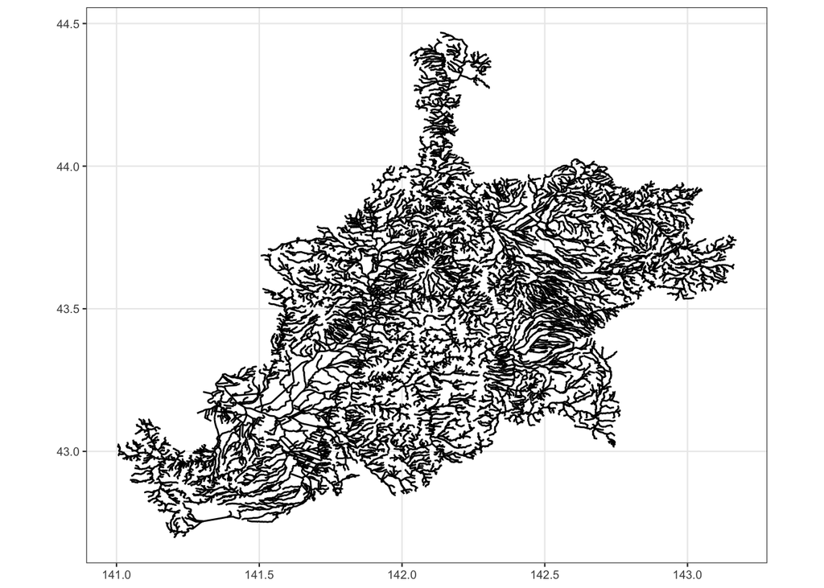

crsが未設定だとx軸とy軸はただの値が表示される

```r
# crs未設定
ggplot(ishikari) + geom_sf()
```

```r
cap = "crsが未設定だとx軸とy軸はただの値が表示される"
```

[figure not shown]

crsを設定すると緯度軽度表示になっていることがわかる

```r
# crsを追加する
st_crs(ishikari) = "+proj=longlat +ellps=WGS84 +datum=WGS84 +no_defs"

ggplot(ishikari) + geom_sf() + geom_sf(data = loc, inherit.aes = FALSE)
```

```r
cap = "crsを設定すると緯度軽度表示になっていることがわかる"
```

## ポイントデータの追加

```r
loc <- st_read("pointdata.csv",
  options = c("X_POSSIBLE_NAMES=lon","Y_POSSIBLE_NAMES=lat"), quiet = TRUE)
st_crs(loc) <- "+proj=longlat +ellps=WGS84 +datum=WGS84 +no_defs"
```

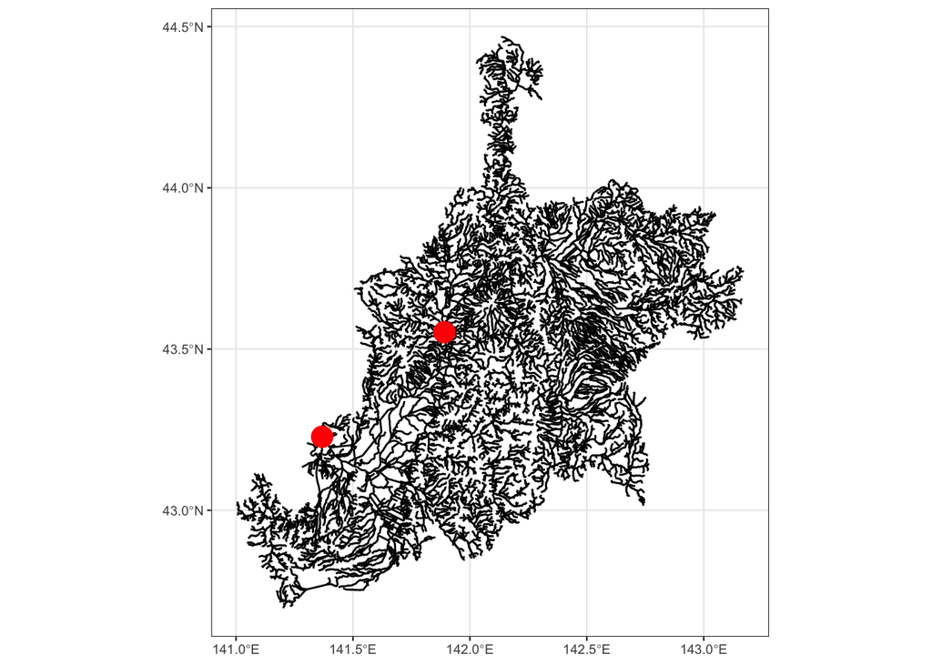

```r
ggplot(ishikari) + geom_sf() +
  geom_sf(data = loc, inherit.aes = FALSE, color = "red", size = 5)
```

## ネットワークの作成

riverdistではネットワークを作るところから始まる。 ラインが細かすぎると処理が遅いのでデータの区間を限定したほうがよい。 今回は区間種別でフィルターを作成するが、QGISなどですでに処理済みのデータを作成しておいてもよい

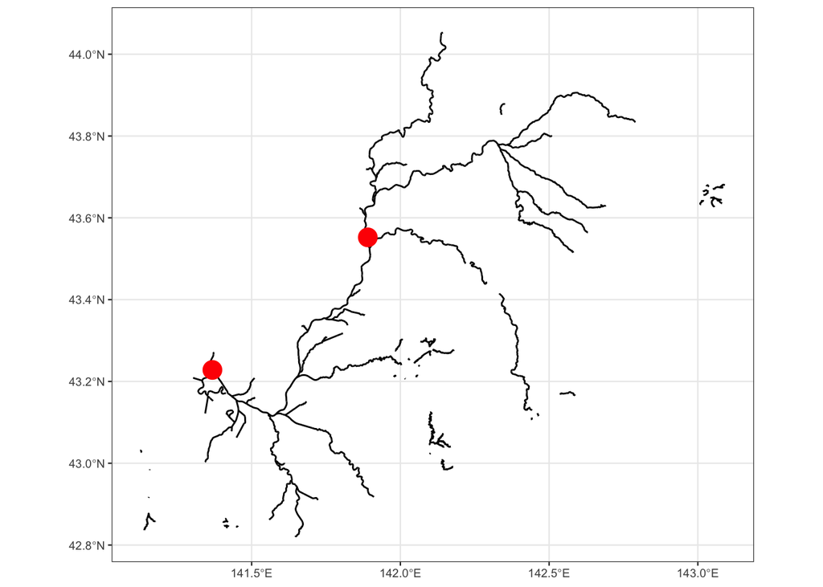

```r
ishikari_filtered <-  ishikari %>% mutate(type = as.numeric(type)) %>%
  filter(type == 1)

ggplot(ishikari_filtered) + geom_sf() +
  geom_sf(data = loc, inherit.aes = FALSE, color = "red", size = 5)
```

### 作業

1. UTM座標系に変換
2. `spatial dataframe`にデータ形式を変更する
3. `line2network()`でネットワークを作成する

```r
# UTM座標系に変換
ishikari_utm <- st_transform(ishikari_filtered, "+init=epsg:32654")
ishikari_river_network <- line2network(as_Spatial(ishikari_utm))
```

```
##
##  Units: m
##
##  Removed 16 segments with lengths shorter than the connectivity tolerance.
```

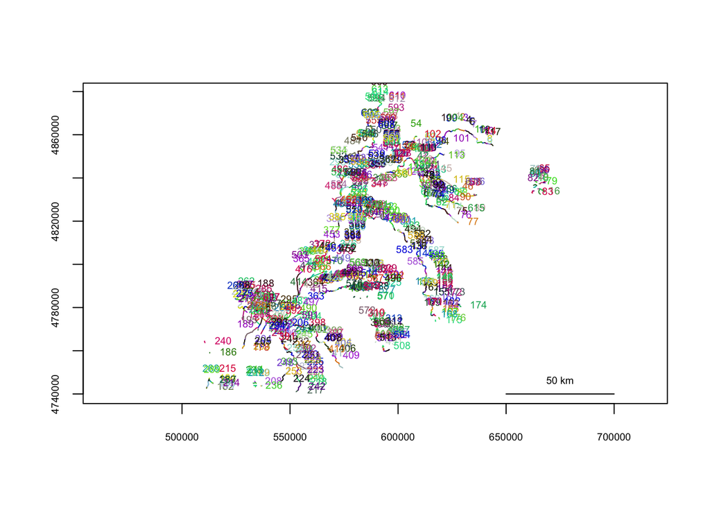

```r
plot(ishikaririve_network)
```

## 河川中でのポイントデータの位置を計算する

```r
# ポイントデータをutm座標系に変換する
points <- st_transform(loc, "+init=epsg:32654") %>%
  mutate(
    x = st_coordinates(geometry)[, 1],
    y = st_coordinates(geometry)[, 2]
  )

# ポイントデータのriver networkの中での位置を算出する
locs_in_river <- xy2segvert(
  x = points$x, y = points$y,
  rivers = ishikari_river_network)
```

## 距離を算出する

```r
# 距離行列を算出する
distmat <- riverdistancemat(
  locs_in_river$seg, locs_in_river$vert, ishikari_river_network
)
```

## 参考URL

### shape fileについて

- [国土数値情報ダウンロードサービス:河川](https://nlftp.mlit.go.jp/ksj/gml/datalist/KsjTmplt-W05.html)

### sf

- [RでGISをやるときにはsfパッケージ、という世の中になるらしい。](https://notchained.hatenablog.com/entry/2017/01/06/213333)
- [sfパッケージを用いてRでの空間データの取り扱いを学ぶ](https://tsukubar.github.io/r-spatial-guide/simple-feature-for-r.html):
  - sfからspへの変換
- [Load a CSV as Simple Features R](https://gis.stackexchange.com/questions/305403/load-a-csv-as-simple-features-r): csvファイルをsfで読み込む
- [Rを使った地理空間情報データの処理～その2～](https://qiita.com/iwasaki_kenichi/items/e2f0c6777263a93c7230): 座標系の設定と変換について
- [CRSの追加](https://keita43a.hatenablog.com/entry/2018/10/24/004341)